# Historical Oxford data

**Reza Sameni**  
Emory University

Data preparation and evaluation of held-out forecasts.

## Topics

- Read preserved Oxford column names.
- Audit reporting corrections and geographic keys.
- Evaluate future cases without fitting them.

**Run:** install the package with `python -m pip install -e ".[notebooks,dev]"`, then run all cells in order. All numerical functions are imported from `src/epidemic_modeling`.

```python
from pathlib import Path
import numpy as np
import pandas as pd
import matplotlib.pyplot as plt
from IPython.display import display, Image, HTML
import epidemic_modeling as em
from epidemic_modeling.plotting import (
    configure_plots,
    repository_root,
    plot_compartments,
    plot_growth,
)

root = repository_root()
configure_plots()
print(f"epidemic_modeling {em.__version__} · local data")
```

```
epidemic_modeling 2.0.0 · local data
```

## Read the bundled snapshot

`OxCGRT_latest.csv` is the original repository's historical snapshot. We display its actual date range. Blank region names denote national entries. National and subnational observations must be kept separate.

```
114,800 rows · 2020-01-01 to 2021-02-13
```

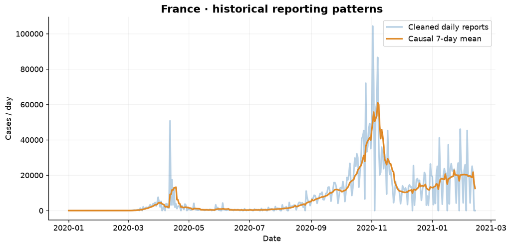

|  | CountryName | RegionName | Date | ConfirmedCases |
| --- | --- | --- | --- | --- |
| 41405 | France |  | 2021-02-09 | 3345558.0 |
| 41406 | France |  | 2021-02-10 | 3370645.0 |
| 41407 | France |  | 2021-02-11 | 3390952.0 |
| 41408 | France |  | 2021-02-12 | 3390952.0 |
| 41409 | France |  | 2021-02-13 | NaN |

```python
data = em.read_oxford_data(root / "data/OxCGRT_latest.csv")
print(f"{len(data):,} rows · {data.Date.min().date()} to {data.Date.max().date()}")
country = "France"
series = data[(data.CountryName == country) & (data.RegionName == "")].copy()
daily, smoothed = em.prepare_cases(series.ConfirmedCases.to_numpy())
fig, ax = plt.subplots()
ax.plot(series.Date, daily, alpha=0.3, label="Cleaned daily reports")
ax.plot(series.Date, smoothed, label="Causal 7-day mean")
ax.set(
    title=f"{country} · historical reporting patterns",
    xlabel="Date",
    ylabel="Cases / day",
)
ax.legend()
plt.show()
display(series[["CountryName", "RegionName", "Date", "ConfirmedCases"]].tail())
```

## A reproducible held-out slice

The final 14 days form the scoring period. Fit the model using only the preceding 100 days. Held-out intervention schedules are scenario inputs; future case counts are reserved for evaluation. Negative daily revisions are clipped and the first training difference is zero.

|  | Days | MAE | RMSE | Bias |
| --- | --- | --- | --- | --- |
| 0 | 14 | NaN | NaN | NaN |

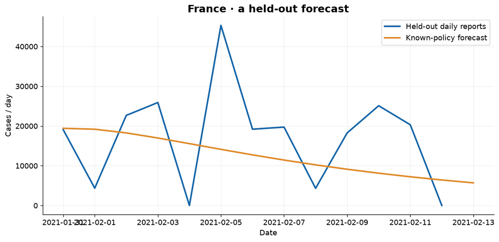

```python
sample = series.tail(114).copy()
train, test = sample.iloc[:-14], sample.iloc[-14:]
columns = list(em.NPI_COLUMNS)
inputs = sample[columns].ffill().fillna(0).to_numpy(float).T
# Read the same bundled population table used by MATLAB.
populations = pd.read_csv(root / "data/populations.csv").fillna({"RegionName": ""})
population = float(
    populations[
        (populations.CountryName == country) & (populations.RegionName == "")
    ].Population2020.iloc[0]
)
model = em.fit_npi_model(
    train.ConfirmedCases.to_numpy(), inputs[:, :-14], population, em.NPI_MAXES
)
predicted, _ = em.forecast_npi(model, inputs[:, -14:])
actual = np.maximum(
    0, np.diff(np.r_[train.ConfirmedCases.iloc[-1], test.ConfirmedCases.to_numpy()])
)
error = predicted - actual
display(
    pd.DataFrame(
        {
            "Days": [len(test)],
            "MAE": [np.mean(np.abs(error))],
            "RMSE": [np.sqrt(np.mean(error**2))],
            "Bias": [np.mean(error)],
        }
    ).round(2)
)
fig, ax = plt.subplots()
ax.plot(test.Date, actual, label="Held-out daily reports")
ax.plot(test.Date, predicted, label="Known-policy forecast")
ax.set(title="France · a held-out forecast", xlabel="Date", ylabel="Cases / day")
ax.legend()
plt.show()
```

## Existing research illustration

The contact-rate estimate in the original US study provides a complementary example of retrospective estimation. It uses a different experiment and dataset interval from the held-out France exercise.

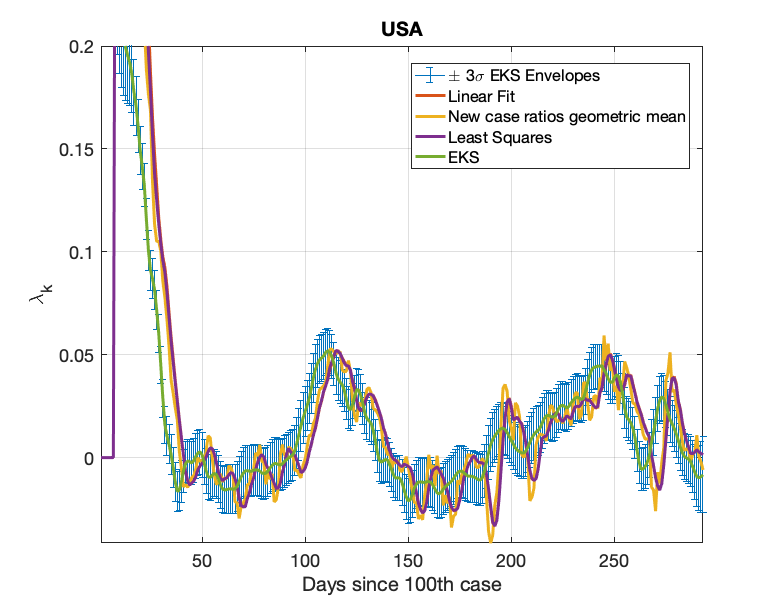

```python
display(Image(filename=str(root / "figures/LambdaEKSUSA.png"), width=700))
```

## Further experiments

- Repeat the slice for Germany, using its own population row.
- Show how centered smoothing could leak held-out information.
- Evaluate more than one cutoff before describing general forecast quality.
- Use `train_npi_prescriptor` and `forecast_quality_assessment` to run CSV-driven batch experiments.

**Paired MATLAB example:** `demo_historical_data`.

## References and next steps

1. Reza Sameni (2020). *Mathematical Modeling of Epidemic Diseases; A Case Study of the COVID-19 Coronavirus*. [arXiv:2003.11371](https://arxiv.org/abs/2003.11371).
2. Reza Sameni (2022). *Model-Based Prediction and Optimal Control of Pandemics by Non-Pharmaceutical Interventions*. IEEE JSTSP, **16**(2), 307–317. [DOI:10.1109/JSTSP.2021.3129118](https://doi.org/10.1109/JSTSP.2021.3129118).

Equations and existing research images originate from the cited work and the [original repository](https://github.com/alphanumericslab/EpidemicModeling). Consult `docs/api.md` for array shapes and `docs/migration.md` for deliberate fixes.